# 3_duplicate_report_nb

## Duplicate Orders and Non-Duplicate Orders Report Summary

##### In this report we go through some general trend of Duplicate Orders and show some valuable insights. Also we will conver some high level stats on the correct orders.

**Definition (Exact Match Duplicate):**  
Exact match duplicates are orders that are identical across all key fields. This includes the vendor name, product list, item codes, quantities, and other relevant metadata.

**Scenario:**  
These are usually the result of customers submitting the same email or form multiple times, either due to a mistake or a system glitch.

**Detection Logic:**  
Compare rows across all relevant fields (e.g., customer_name, po_number, item_description, item_code, quantity).  
Identify rows that are completely identical or repeated.

**Definition (Fuzzy Match Duplicates):**  
Fuzzy match duplicates are orders that are not identical but are very similar, with minor differences like spelling variations, formatting inconsistencies, or shuffled product listings.

**Scenario:**  
These often arise when:

A customer submits the same order with slight modifications (e.g., typo correction).

Orders are manually typed or translated, leading to inconsistent representations.

The item list is the same but the order is changed (e.g., reordered product lines).

**Detection Logic:**  
Use fuzzy string matching (e.g., Partial Token Set Ratio from fuzzywuzzy) on combinations of fields like customer_name, product_name, and item_code which calculates the similarity of two strings by calculating the Levenshtein distance.

Define a similarity threshold (e.g., ≥ 90%) to flag potential duplicates.

### For the sake of showing fuzzy characteristics, I have added two dummy emails with few changes in the product and vendor names.I have also added the Dummy Emails in the folder for reference.

```
=== Exact Duplicates Across Mails ===
    po_number_1  po_number_2              vendor  units      product_name Corrected_Item_Code
0            11           13           Brown_Inc    299    Heat Exchanger             HE-2512
1            11           13           Brown_Inc    167    Heat Exchanger             HE-2512
2            11           13           Brown_Inc    230    Motor Assembly             MA-2200
3             7           56     Garcia_Services    181    Motor Assembly             MA-2200
4             7           56     Garcia_Services    273    Motor Assembly             MA-2200
5            32           15        Hernandez_Co    402       Bearing Set             BS-7890
6             6            3      Lewis_Supplies    375   Compressor Unit             CU-5643
7            34           42    Martin_Solutions    319   Compressor Unit             CU-5643
8            29           33        Martinez_Llc    375     Conveyor Belt             CB-3300
9             5           49          Smith_Corp    135    Hydraulic Pump             HP-1001
10            5           49          Smith_Corp    135    Heat Exchanger             HE-2512
11            5           49          Smith_Corp    155     Conveyor Belt             CB-3300
12           14           51          Smith_Corp    397   Compressor Unit             CU-5643
13           39           41  Taylor_Enterprises    127    Heat Exchanger             HE-2512
14           39           41  Taylor_Enterprises     14   Compressor Unit             CU-5643
15           24           25  Walker_Enterprises     93     Control Valve             CV-6677
16           24           25  Walker_Enterprises    274  Electrical Panel             EP-9012
17           24           25  Walker_Enterprises    436     Control Valve             CV-6677
18           37           44         Young_Group     30      Gear Reducer             GR-4500
19           37           44         Young_Group    419    Hydraulic Pump             HP-1001
20           37           44         Young_Group    484    Motor Assembly             MA-2200

=== Fuzzy Duplicates Across Mails ===
   po_number_1  po_number_2   units  product_name_1 product_name_2    vendor_1     vendor_2  Product_Score  Customer_Score
0           12           24  100000     Bearing Set   Bearing Sets  Dummy_Corp  Dummy_Corps            100             100
1           12           24  500000  Heat Exhangers  Hear Exhanger  Dummy_Corp  Dummy_Corps             92             100
```

## The next series of graphs contains the Duplicate Order Summary

The report contains the following graph (left to right):  
1. % of Units flagged as duplicates.  
2. Top customers with the most duplicate submissions.  
3. Duplicate trends over time.  
4. Percentage of duplicates per customer  
5. Original vs Duplicate Order Units per Product Category

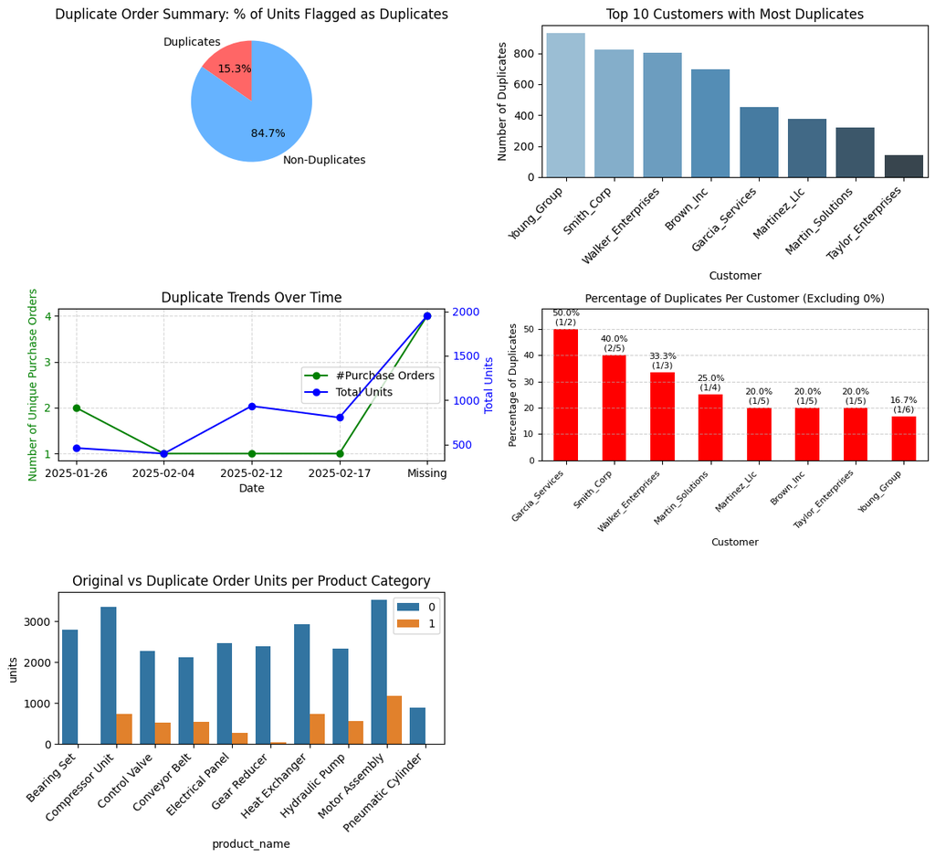

## General Orders Report Summary (Excluding Duplicates)

The report contains the following graph (left to right):  
1. Orders per customer  
2. Top products  
3. Order trend over delivery deadline date  
4. Average order size per customer  
5. Distribution of order sizes  
6. Orders per month (alternative view)

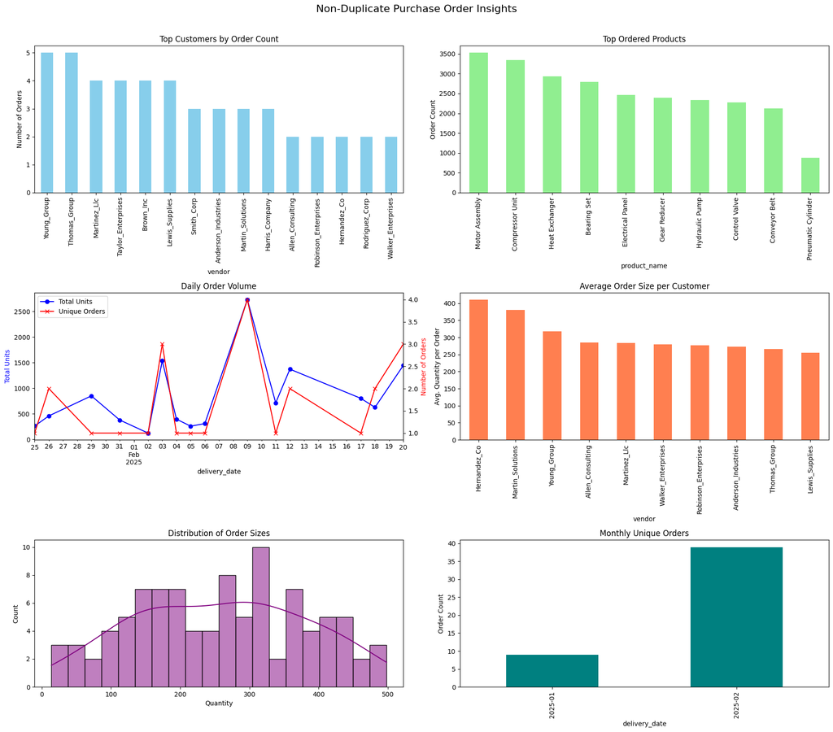